# Optimal Treatment Analysis

## Outcome Variable

**Outcome Variable:** ever_stunted

## Predictor Variables

**Intervention Variable:** predfeed3

**Adjustment Set:**

- arm
- sex
- month
- brthmon
- W_mage
- meducyrs
- feducyrs
- hhwealth_quart
- hfoodsec
- W_mhtcm
- vagbrth
- W_gagebrth
- W_birthwt
- W_birthlen
- W_nrooms
- W_nchldlt5
- W_parity
- impfloor
- impsan
- safeh20
- delta_W_mage
- delta_meducyrs
- delta_feducyrs
- delta_hhwealth_quart
- delta_hfoodsec
- delta_W_mhtcm
- delta_vagbrth
- delta_W_gagebrth
- delta_W_birthwt
- delta_W_birthlen
- delta_W_nrooms
- delta_W_nchldlt5
- delta_W_parity
- delta_impfloor
- delta_impsan
- delta_safeh20

## Stratifying Variables

The analysis was stratified on these variable(s):

- agecat
- studyid
- country

## Data Summary

| agecat | studyid | country | predfeed3 | ever_stunted | n_cell | n |
| --- | --- | --- | --- | --- | --- | --- |
| 0-24 months (no birth st.) | ki0047075b-MAL-ED | BANGLADESH | 0 | 0 | 13 | 206 |
| 0-24 months (no birth st.) | ki0047075b-MAL-ED | BANGLADESH | 0 | 1 | 17 | 206 |
| 0-24 months (no birth st.) | ki0047075b-MAL-ED | BANGLADESH | 1 | 0 | 85 | 206 |
| 0-24 months (no birth st.) | ki0047075b-MAL-ED | BANGLADESH | 1 | 1 | 91 | 206 |
| 0-24 months (no birth st.) | ki0047075b-MAL-ED | BRAZIL | 0 | 0 | 81 | 202 |
| 0-24 months (no birth st.) | ki0047075b-MAL-ED | BRAZIL | 0 | 1 | 11 | 202 |
| 0-24 months (no birth st.) | ki0047075b-MAL-ED | BRAZIL | 1 | 0 | 93 | 202 |
| 0-24 months (no birth st.) | ki0047075b-MAL-ED | BRAZIL | 1 | 1 | 17 | 202 |
| 0-24 months (no birth st.) | ki0047075b-MAL-ED | INDIA | 0 | 0 | 33 | 200 |
| 0-24 months (no birth st.) | ki0047075b-MAL-ED | INDIA | 0 | 1 | 12 | 200 |
| 0-24 months (no birth st.) | ki0047075b-MAL-ED | INDIA | 1 | 0 | 61 | 200 |
| 0-24 months (no birth st.) | ki0047075b-MAL-ED | INDIA | 1 | 1 | 94 | 200 |
| 0-24 months (no birth st.) | ki0047075b-MAL-ED | NEPAL | 0 | 0 | 63 | 209 |
| 0-24 months (no birth st.) | ki0047075b-MAL-ED | NEPAL | 0 | 1 | 22 | 209 |
| 0-24 months (no birth st.) | ki0047075b-MAL-ED | NEPAL | 1 | 0 | 91 | 209 |
| 0-24 months (no birth st.) | ki0047075b-MAL-ED | NEPAL | 1 | 1 | 33 | 209 |
| 0-24 months (no birth st.) | ki0047075b-MAL-ED | PERU | 0 | 0 | 29 | 251 |
| 0-24 months (no birth st.) | ki0047075b-MAL-ED | PERU | 0 | 1 | 52 | 251 |
| 0-24 months (no birth st.) | ki0047075b-MAL-ED | PERU | 1 | 0 | 72 | 251 |
| 0-24 months (no birth st.) | ki0047075b-MAL-ED | PERU | 1 | 1 | 98 | 251 |
| 0-24 months (no birth st.) | ki0047075b-MAL-ED | SOUTH AFRICA | 0 | 0 | 77 | 246 |
| 0-24 months (no birth st.) | ki0047075b-MAL-ED | SOUTH AFRICA | 0 | 1 | 81 | 246 |
| 0-24 months (no birth st.) | ki0047075b-MAL-ED | SOUTH AFRICA | 1 | 0 | 37 | 246 |
| 0-24 months (no birth st.) | ki0047075b-MAL-ED | SOUTH AFRICA | 1 | 1 | 51 | 246 |
| 0-24 months (no birth st.) | ki0047075b-MAL-ED | TANZANIA, UNITED REPUBLIC OF | 0 | 0 | 19 | 211 |
| 0-24 months (no birth st.) | ki0047075b-MAL-ED | TANZANIA, UNITED REPUBLIC OF | 0 | 1 | 109 | 211 |
| 0-24 months (no birth st.) | ki0047075b-MAL-ED | TANZANIA, UNITED REPUBLIC OF | 1 | 0 | 17 | 211 |
| 0-24 months (no birth st.) | ki0047075b-MAL-ED | TANZANIA, UNITED REPUBLIC OF | 1 | 1 | 66 | 211 |
| 0-24 months (no birth st.) | ki1000109-EE | PAKISTAN | 0 | 0 | 4 | 496 |
| 0-24 months (no birth st.) | ki1000109-EE | PAKISTAN | 0 | 1 | 28 | 496 |

[output cut: 102 more lines]

The following strata were considered:

- agecat: 0-24 months (no birth st.), studyid: ki0047075b-MAL-ED, country: BANGLADESH
- agecat: 0-24 months (no birth st.), studyid: ki0047075b-MAL-ED, country: BRAZIL
- agecat: 0-24 months (no birth st.), studyid: ki0047075b-MAL-ED, country: INDIA
- agecat: 0-24 months (no birth st.), studyid: ki0047075b-MAL-ED, country: NEPAL
- agecat: 0-24 months (no birth st.), studyid: ki0047075b-MAL-ED, country: PERU
- agecat: 0-24 months (no birth st.), studyid: ki0047075b-MAL-ED, country: SOUTH AFRICA
- agecat: 0-24 months (no birth st.), studyid: ki0047075b-MAL-ED, country: TANZANIA, UNITED REPUBLIC OF
- agecat: 0-24 months (no birth st.), studyid: ki1000109-EE, country: PAKISTAN
- agecat: 0-24 months (no birth st.), studyid: ki1113344-GMS-Nepal, country: NEPAL
- agecat: 0-24 months (no birth st.), studyid: kiGH5241-JiVitA-3, country: BANGLADESH
- agecat: 0-24 months (no birth st.), studyid: kiGH5241-JiVitA-4, country: BANGLADESH
- agecat: 0-6 months (no birth st.), studyid: ki0047075b-MAL-ED, country: BANGLADESH
- agecat: 0-6 months (no birth st.), studyid: ki0047075b-MAL-ED, country: BRAZIL
- agecat: 0-6 months (no birth st.), studyid: ki0047075b-MAL-ED, country: INDIA
- agecat: 0-6 months (no birth st.), studyid: ki0047075b-MAL-ED, country: NEPAL
- agecat: 0-6 months (no birth st.), studyid: ki0047075b-MAL-ED, country: PERU
- agecat: 0-6 months (no birth st.), studyid: ki0047075b-MAL-ED, country: SOUTH AFRICA
- agecat: 0-6 months (no birth st.), studyid: ki0047075b-MAL-ED, country: TANZANIA, UNITED REPUBLIC OF
- agecat: 0-6 months (no birth st.), studyid: ki1000109-EE, country: PAKISTAN
- agecat: 0-6 months (no birth st.), studyid: ki1113344-GMS-Nepal, country: NEPAL
- agecat: 0-6 months (no birth st.), studyid: kiGH5241-JiVitA-3, country: BANGLADESH
- agecat: 0-6 months (no birth st.), studyid: kiGH5241-JiVitA-4, country: BANGLADESH
- agecat: 6-24 months, studyid: ki0047075b-MAL-ED, country: BANGLADESH
- agecat: 6-24 months, studyid: ki0047075b-MAL-ED, country: BRAZIL
- agecat: 6-24 months, studyid: ki0047075b-MAL-ED, country: INDIA
- agecat: 6-24 months, studyid: ki0047075b-MAL-ED, country: NEPAL
- agecat: 6-24 months, studyid: ki0047075b-MAL-ED, country: PERU
- agecat: 6-24 months, studyid: ki0047075b-MAL-ED, country: SOUTH AFRICA
- agecat: 6-24 months, studyid: ki0047075b-MAL-ED, country: TANZANIA, UNITED REPUBLIC OF
- agecat: 6-24 months, studyid: ki1000109-EE, country: PAKISTAN
- agecat: 6-24 months, studyid: ki1113344-GMS-Nepal, country: NEPAL
- agecat: 6-24 months, studyid: kiGH5241-JiVitA-3, country: BANGLADESH
- agecat: 6-24 months, studyid: kiGH5241-JiVitA-4, country: BANGLADESH

### Dropped Strata

Some strata were dropped due to rare outcomes:

- agecat: 0-24 months (no birth st.), studyid: ki1000109-EE, country: PAKISTAN
- agecat: 6-24 months, studyid: ki0047075b-MAL-ED, country: BRAZIL
- agecat: 6-24 months, studyid: ki1000109-EE, country: PAKISTAN

## Methods Detail

We’re interested in the causal parameters $E[Y_a]$ for all values of $a \in \mathcal{A}$. These parameters represent the mean outcome if, possibly contrary to fact, we intervened to set all units to have $A=a$. Under the randomization and positivity assumptions, these are identified by the statistical parameters $\psi_a=E_W[E_{Y|A,W}(Y|A=a,W)]$. In addition, we’re interested in the mean of $Y$, $E[Y]$ under no intervention (the observed mean). We will estimate these parameters by using SuperLearner to fit the relevant likelihood factors – $E_{Y|A,W}(Y|A=a,W)$ and $p(A=a|W)$, and then updating our likelihood fit using a joint TMLE.

For unadjusted analyses ($W=\{\}$), initial likelihoods were estimated using Lrnr_glm to estimate the simple $E(Y|A)$ and Lrnr_mean to estimate $p(A)$. For adjusted analyses, a small library containing Lrnr_glmnet, Lrnr_xgboost, and Lrnr_mean was used.

Having estimated these parameters, we will then use the delta method to estimate relative risks and attributable risks relative to a prespecified baseline level of $A$.

# Results Detail

## Results Plots

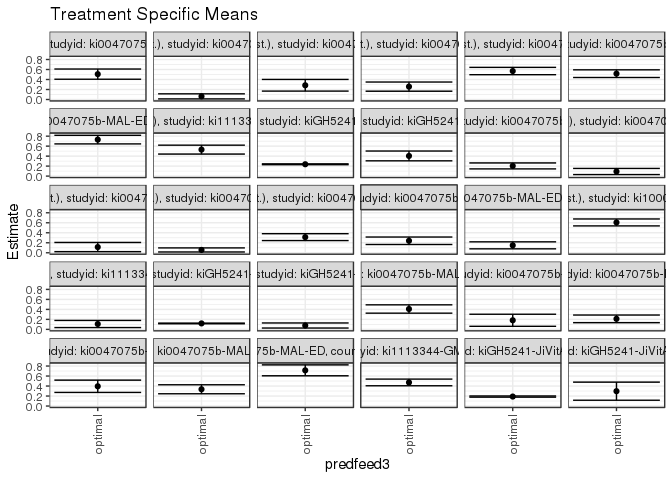

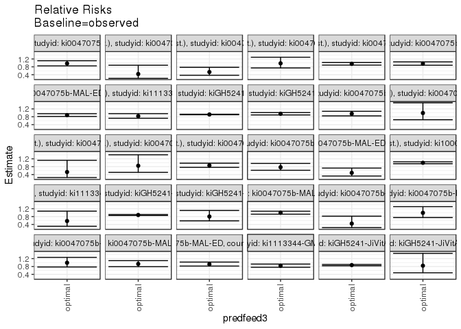

## Results Table

### Parameter: TSM

| agecat | studyid | country | intervention_level | baseline_level | estimate | ci_lower | ci_upper |
| --- | --- | --- | --- | --- | --- | --- | --- |
| 0-24 months (no birth st.) | ki0047075b-MAL-ED | BANGLADESH | optimal | NA | 0.5070843 | 0.4049194 | 0.6092492 |
| 0-24 months (no birth st.) | ki0047075b-MAL-ED | BRAZIL | optimal | NA | 0.0623677 | 0.0114811 | 0.1132543 |
| 0-24 months (no birth st.) | ki0047075b-MAL-ED | INDIA | optimal | NA | 0.2842989 | 0.1674131 | 0.4011847 |
| 0-24 months (no birth st.) | ki0047075b-MAL-ED | NEPAL | optimal | NA | 0.2574354 | 0.1656872 | 0.3491837 |
| 0-24 months (no birth st.) | ki0047075b-MAL-ED | PERU | optimal | NA | 0.5693006 | 0.4956497 | 0.6429514 |
| 0-24 months (no birth st.) | ki0047075b-MAL-ED | SOUTH AFRICA | optimal | NA | 0.5165613 | 0.4396008 | 0.5935219 |
| 0-24 months (no birth st.) | ki0047075b-MAL-ED | TANZANIA, UNITED REPUBLIC OF | optimal | NA | 0.7307864 | 0.6443711 | 0.8172016 |
| 0-24 months (no birth st.) | ki1113344-GMS-Nepal | NEPAL | optimal | NA | 0.5305416 | 0.4411992 | 0.6198840 |
| 0-24 months (no birth st.) | kiGH5241-JiVitA-3 | BANGLADESH | optimal | NA | 0.2375691 | 0.2292019 | 0.2459362 |
| 0-24 months (no birth st.) | kiGH5241-JiVitA-4 | BANGLADESH | optimal | NA | 0.4038181 | 0.3057685 | 0.5018676 |
| 0-6 months (no birth st.) | ki0047075b-MAL-ED | BANGLADESH | optimal | NA | 0.2041634 | 0.1444254 | 0.2639015 |
| 0-6 months (no birth st.) | ki0047075b-MAL-ED | BRAZIL | optimal | NA | 0.0925755 | 0.0310778 | 0.1540731 |
| 0-6 months (no birth st.) | ki0047075b-MAL-ED | INDIA | optimal | NA | 0.1138626 | 0.0218080 | 0.2059173 |
| 0-6 months (no birth st.) | ki0047075b-MAL-ED | NEPAL | optimal | NA | 0.0567445 | 0.0160253 | 0.0974637 |
| 0-6 months (no birth st.) | ki0047075b-MAL-ED | PERU | optimal | NA | 0.3122595 | 0.2436428 | 0.3808761 |
| 0-6 months (no birth st.) | ki0047075b-MAL-ED | SOUTH AFRICA | optimal | NA | 0.2397043 | 0.1650056 | 0.3144029 |
| 0-6 months (no birth st.) | ki0047075b-MAL-ED | TANZANIA, UNITED REPUBLIC OF | optimal | NA | 0.1482168 | 0.0783729 | 0.2180607 |
| 0-6 months (no birth st.) | ki1000109-EE | PAKISTAN | optimal | NA | 0.6064645 | 0.5370905 | 0.6758384 |
| 0-6 months (no birth st.) | ki1113344-GMS-Nepal | NEPAL | optimal | NA | 0.1077936 | 0.0365819 | 0.1790053 |
| 0-6 months (no birth st.) | kiGH5241-JiVitA-3 | BANGLADESH | optimal | NA | 0.1193448 | 0.1131687 | 0.1255209 |
| 0-6 months (no birth st.) | kiGH5241-JiVitA-4 | BANGLADESH | optimal | NA | 0.0775364 | 0.0265447 | 0.1285282 |
| 6-24 months | ki0047075b-MAL-ED | BANGLADESH | optimal | NA | 0.4081111 | 0.3249595 | 0.4912626 |
| 6-24 months | ki0047075b-MAL-ED | INDIA | optimal | NA | 0.1823283 | 0.0614916 | 0.3031650 |
| 6-24 months | ki0047075b-MAL-ED | NEPAL | optimal | NA | 0.2109301 | 0.1343660 | 0.2874943 |
| 6-24 months | ki0047075b-MAL-ED | PERU | optimal | NA | 0.3950295 | 0.2719974 | 0.5180616 |
| 6-24 months | ki0047075b-MAL-ED | SOUTH AFRICA | optimal | NA | 0.3352271 | 0.2449548 | 0.4254993 |
| 6-24 months | ki0047075b-MAL-ED | TANZANIA, UNITED REPUBLIC OF | optimal | NA | 0.7141651 | 0.6046071 | 0.8237230 |
| 6-24 months | ki1113344-GMS-Nepal | NEPAL | optimal | NA | 0.4720831 | 0.4052569 | 0.5389092 |
| 6-24 months | kiGH5241-JiVitA-3 | BANGLADESH | optimal | NA | 0.1893446 | 0.1777466 | 0.2009427 |
| 6-24 months | kiGH5241-JiVitA-4 | BANGLADESH | optimal | NA | 0.2966445 | 0.1152805 | 0.4780085 |

### Parameter: E(Y)

| agecat | studyid | country | intervention_level | baseline_level | estimate | ci_lower | ci_upper |
| --- | --- | --- | --- | --- | --- | --- | --- |
| 0-24 months (no birth st.) | ki0047075b-MAL-ED | BANGLADESH | observed | NA | 0.5222946 | 0.4539304 | 0.5906589 |
| 0-24 months (no birth st.) | ki0047075b-MAL-ED | BRAZIL | observed | NA | 0.1429240 | 0.0951543 | 0.1906937 |
| 0-24 months (no birth st.) | ki0047075b-MAL-ED | INDIA | observed | NA | 0.5301603 | 0.4608164 | 0.5995042 |
| 0-24 months (no birth st.) | ki0047075b-MAL-ED | NEPAL | observed | NA | 0.2630115 | 0.2031688 | 0.3228543 |
| 0-24 months (no birth st.) | ki0047075b-MAL-ED | PERU | observed | NA | 0.5981984 | 0.5374114 | 0.6589854 |
| 0-24 months (no birth st.) | ki0047075b-MAL-ED | SOUTH AFRICA | observed | NA | 0.5368549 | 0.4744140 | 0.5992958 |
| 0-24 months (no birth st.) | ki0047075b-MAL-ED | TANZANIA, UNITED REPUBLIC OF | observed | NA | 0.8280050 | 0.7771275 | 0.8788826 |
| 0-24 months (no birth st.) | ki1113344-GMS-Nepal | NEPAL | observed | NA | 0.6377048 | 0.5917832 | 0.6836263 |
| 0-24 months (no birth st.) | kiGH5241-JiVitA-3 | BANGLADESH | observed | NA | 0.2593523 | 0.2512676 | 0.2674370 |
| 0-24 months (no birth st.) | kiGH5241-JiVitA-4 | BANGLADESH | observed | NA | 0.4245122 | 0.3310687 | 0.5179557 |
| 0-6 months (no birth st.) | ki0047075b-MAL-ED | BANGLADESH | observed | NA | 0.2140310 | 0.1579278 | 0.2701343 |
| 0-6 months (no birth st.) | ki0047075b-MAL-ED | BRAZIL | observed | NA | 0.0934978 | 0.0531425 | 0.1338532 |
| 0-6 months (no birth st.) | ki0047075b-MAL-ED | INDIA | observed | NA | 0.2154305 | 0.1583516 | 0.2725094 |
| 0-6 months (no birth st.) | ki0047075b-MAL-ED | NEPAL | observed | NA | 0.0669762 | 0.0330018 | 0.1009506 |
| 0-6 months (no birth st.) | ki0047075b-MAL-ED | PERU | observed | NA | 0.3610103 | 0.3014187 | 0.4206019 |
| 0-6 months (no birth st.) | ki0047075b-MAL-ED | SOUTH AFRICA | observed | NA | 0.3103903 | 0.2525326 | 0.3682480 |
| 0-6 months (no birth st.) | ki0047075b-MAL-ED | TANZANIA, UNITED REPUBLIC OF | observed | NA | 0.3047700 | 0.2425966 | 0.3669434 |
| 0-6 months (no birth st.) | ki1000109-EE | PAKISTAN | observed | NA | 0.6077580 | 0.5467893 | 0.6687266 |
| 0-6 months (no birth st.) | ki1113344-GMS-Nepal | NEPAL | observed | NA | 0.1872221 | 0.1499610 | 0.2244832 |
| 0-6 months (no birth st.) | kiGH5241-JiVitA-3 | BANGLADESH | observed | NA | 0.1354104 | 0.1296133 | 0.1412075 |
| 0-6 months (no birth st.) | kiGH5241-JiVitA-4 | BANGLADESH | observed | NA | 0.0963749 | 0.0427185 | 0.1500313 |
| 6-24 months | ki0047075b-MAL-ED | BANGLADESH | observed | NA | 0.4101531 | 0.3327173 | 0.4875888 |
| 6-24 months | ki0047075b-MAL-ED | INDIA | observed | NA | 0.4097486 | 0.3318423 | 0.4876549 |
| 6-24 months | ki0047075b-MAL-ED | NEPAL | observed | NA | 0.2129384 | 0.1550817 | 0.2707951 |
| 6-24 months | ki0047075b-MAL-ED | PERU | observed | NA | 0.3987862 | 0.3196366 | 0.4779358 |
| 6-24 months | ki0047075b-MAL-ED | SOUTH AFRICA | observed | NA | 0.3593316 | 0.2838134 | 0.4348498 |
| 6-24 months | ki0047075b-MAL-ED | TANZANIA, UNITED REPUBLIC OF | observed | NA | 0.7766965 | 0.7081470 | 0.8452460 |
| 6-24 months | ki1113344-GMS-Nepal | NEPAL | observed | NA | 0.5635333 | 0.5105640 | 0.6165026 |
| 6-24 months | kiGH5241-JiVitA-3 | BANGLADESH | observed | NA | 0.2170336 | 0.2074608 | 0.2266065 |
| 6-24 months | kiGH5241-JiVitA-4 | BANGLADESH | observed | NA | 0.3522650 | 0.2567613 | 0.4477687 |

### Parameter: RR

| agecat | studyid | country | intervention_level | baseline_level | estimate | ci_lower | ci_upper |
| --- | --- | --- | --- | --- | --- | --- | --- |
| 0-24 months (no birth st.) | ki0047075b-MAL-ED | BANGLADESH | optimal | observed | 0.9708779 | 0.8490563 | 1.1101782 |
| 0-24 months (no birth st.) | ki0047075b-MAL-ED | BRAZIL | optimal | observed | 0.4363694 | 0.2161169 | 0.8810893 |
| 0-24 months (no birth st.) | ki0047075b-MAL-ED | INDIA | optimal | observed | 0.5362508 | 0.3704073 | 0.7763479 |
| 0-24 months (no birth st.) | ki0047075b-MAL-ED | NEPAL | optimal | observed | 0.9787990 | 0.7439672 | 1.2877549 |
| 0-24 months (no birth st.) | ki0047075b-MAL-ED | PERU | optimal | observed | 0.9516918 | 0.8881927 | 1.0197306 |
| 0-24 months (no birth st.) | ki0047075b-MAL-ED | SOUTH AFRICA | optimal | observed | 0.9621992 | 0.8812214 | 1.0506182 |
| 0-24 months (no birth st.) | ki0047075b-MAL-ED | TANZANIA, UNITED REPUBLIC OF | optimal | observed | 0.8825869 | 0.8151466 | 0.9556068 |
| 0-24 months (no birth st.) | ki1113344-GMS-Nepal | NEPAL | optimal | observed | 0.8319549 | 0.7236576 | 0.9564592 |
| 0-24 months (no birth st.) | kiGH5241-JiVitA-3 | BANGLADESH | optimal | observed | 0.9160090 | 0.9025419 | 0.9296769 |
| 0-24 months (no birth st.) | kiGH5241-JiVitA-4 | BANGLADESH | optimal | observed | 0.9512519 | 0.8935613 | 1.0126672 |
| 0-6 months (no birth st.) | ki0047075b-MAL-ED | BANGLADESH | optimal | observed | 0.9538963 | 0.8447009 | 1.0772075 |
| 0-6 months (no birth st.) | ki0047075b-MAL-ED | BRAZIL | optimal | observed | 0.9901350 | 0.6498436 | 1.5086204 |
| 0-6 months (no birth st.) | ki0047075b-MAL-ED | INDIA | optimal | observed | 0.5285353 | 0.2487631 | 1.1229542 |
| 0-6 months (no birth st.) | ki0047075b-MAL-ED | NEPAL | optimal | observed | 0.8472337 | 0.5115564 | 1.4031784 |
| 0-6 months (no birth st.) | ki0047075b-MAL-ED | PERU | optimal | observed | 0.8649599 | 0.7648822 | 0.9781319 |
| 0-6 months (no birth st.) | ki0047075b-MAL-ED | SOUTH AFRICA | optimal | observed | 0.7722674 | 0.6175089 | 0.9658111 |
| 0-6 months (no birth st.) | ki0047075b-MAL-ED | TANZANIA, UNITED REPUBLIC OF | optimal | observed | 0.4863234 | 0.3245990 | 0.7286233 |
| 0-6 months (no birth st.) | ki1000109-EE | PAKISTAN | optimal | observed | 0.9978716 | 0.9500826 | 1.0480645 |
| 0-6 months (no birth st.) | ki1113344-GMS-Nepal | NEPAL | optimal | observed | 0.5757525 | 0.3079822 | 1.0763315 |
| 0-6 months (no birth st.) | kiGH5241-JiVitA-3 | BANGLADESH | optimal | observed | 0.8813563 | 0.8579953 | 0.9053535 |
| 0-6 months (no birth st.) | kiGH5241-JiVitA-4 | BANGLADESH | optimal | observed | 0.8045295 | 0.5822621 | 1.1116431 |
| 6-24 months | ki0047075b-MAL-ED | BANGLADESH | optimal | observed | 0.9950214 | 0.9228782 | 1.0728042 |
| 6-24 months | ki0047075b-MAL-ED | INDIA | optimal | observed | 0.4449760 | 0.2410181 | 0.8215303 |
| 6-24 months | ki0047075b-MAL-ED | NEPAL | optimal | observed | 0.9905689 | 0.7515061 | 1.3056802 |
| 6-24 months | ki0047075b-MAL-ED | PERU | optimal | observed | 0.9905796 | 0.7756051 | 1.2651388 |
| 6-24 months | ki0047075b-MAL-ED | SOUTH AFRICA | optimal | observed | 0.9329183 | 0.7930733 | 1.0974226 |
| 6-24 months | ki0047075b-MAL-ED | TANZANIA, UNITED REPUBLIC OF | optimal | observed | 0.9194905 | 0.8242653 | 1.0257168 |
| 6-24 months | ki1113344-GMS-Nepal | NEPAL | optimal | observed | 0.8377199 | 0.7605581 | 0.9227102 |
| 6-24 months | kiGH5241-JiVitA-3 | BANGLADESH | optimal | observed | 0.8724206 | 0.8389526 | 0.9072238 |
| 6-24 months | kiGH5241-JiVitA-4 | BANGLADESH | optimal | observed | 0.8421061 | 0.4830011 | 1.4682009 |